# 7 CUGN glider time-depth

```r
cciea_yr <- 2024
```

**Description** Time versus depth profiles of water temperatures off of Monterey (66), Pt Conception (80), and north of San Diego (90) demonstrate the extent of recent warm and cool anomalies into the water column, as well as spatial and temporal dynamics of these anomalies.

**Metafile name** Not in CCIEA Metadatabase

**Indicator Category** Climate and Ocean Drivers

**Data Steward** Schroeder

**Erddap Dataset ID** NA

**CCIEA timeseries ID** NA

**Region** Lines 66, 80, 90

**Public availability statement** Source data are publicly available.

**Data sources** Netcdf files of the three lines can be downloaded from https://spraydata.ucsd.edu/projects/CUGN/. The data downloaded are temperature anomalies created by CUGN.

**Additional Information** The temperature anomaly data provided in the netcdf file has data across the line at 5 m intervals over 0-500 m and distances at 5 km from the coat out to the end of the line (66=400 km, 80=365 km, 90=530 km). Distance can be averaged using Python xarray to select specific distance ranges and then averaging over the distances. The time interval of the netcdf file is 10 days and this is shown in Figure 7.2.

**Figures**

[figure not shown]

Figure 7.1: Map CalCOFI line and station sampling stations. CUGN has been sampling lines 66, 80, 90 since 2006.

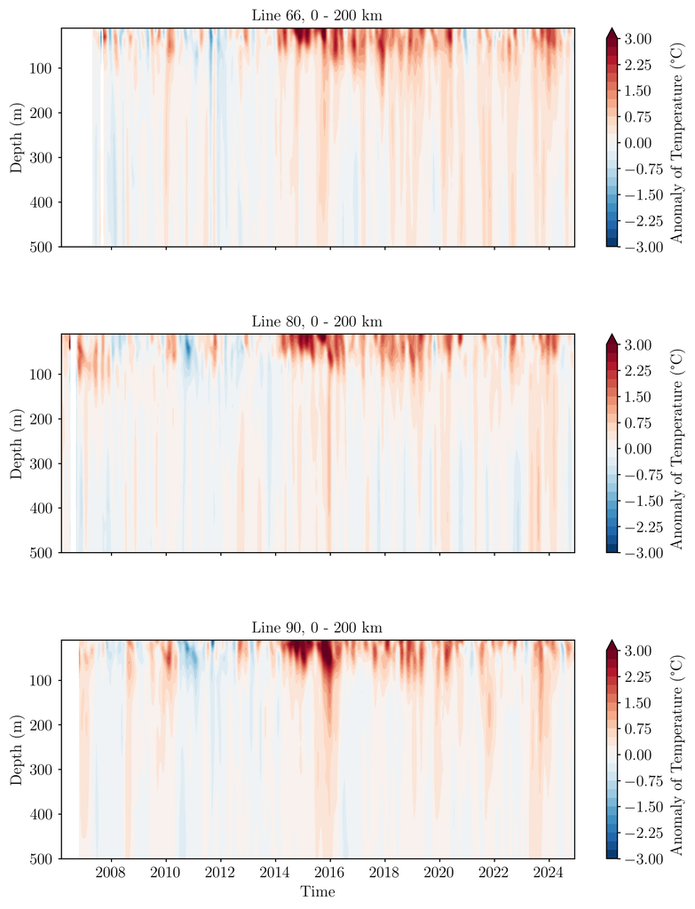

**2024 Conditions**

- Along line 90, winter 2023-24 El Niño influence at the surface (upper 100 m) is not as extreme as the 2016 event (Figure 7.2, bottom).
- All three lines had similar positive anomalies down to 500 m mostly occuring in the fall 2023.